# Embracing Identity: The Dilemma of Indian American Names and Cultural Heritage

05/30/2023

*Rendered at 11:56 PM, Jun. 01, 2023*

*Sherin Stanley (sherinstanley@gmail.com)*

## Overview

Imagine this. You’re on a trip with your family and stop by a souvenir store. You stumble across one of those personalized souvenir carts, that are marketed to contain any name you can think of and after hours of searching, you find nothing. Or you might get lucky and settle for a souvenir that has some semblance to your name, like a magnet with the name “Renee” on it, but your name isn’t Renee. It’s Renita. Upon some reflection regarding the potential consequences of acquiring the magnet and questioning the significance of losing one’s identity, you ponder whether it is truly a matter of great importance or simply an ordinary magnet. “My name is Samir, but I go by Sam,” is what Samir Patel, one of my peers mentioned. He described how while it isn’t too hard to say his real name, it was easier to go by Sam since it made things easier for the people around him. For many Indian American children growing up in the United States, this is a familiar experience. It has reached a point where many parents are opting for more Americanized names for their kids. “I named my daughter Megan, because I wanted her to have a more western sounding name”, is what Anita Rao said. Nevertheless, some choose to retain their traditional names to preserve their cultural heritage. Another shared experience among Indian American children is the sense of connection they feel when encountering someone who shares their name, since many of them go their whole lives without meeting someone who does.

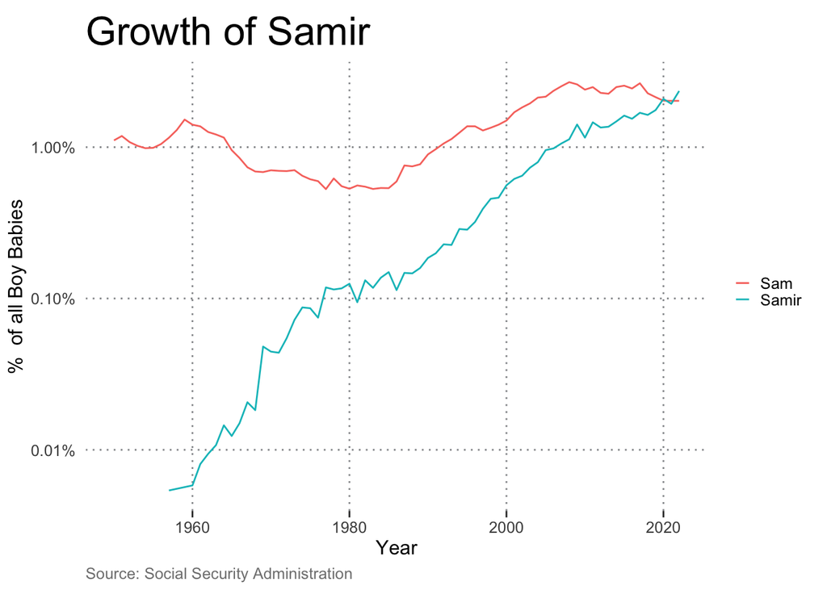

“I don’t come across many Jahnavis,” said UNC-Chapel Hill student, Jahnavi Alapati. ”So it makes sense that my name doesn’t project the same growth as the others.” [The “others” she’s referring to are other Indian names in the US, according to data from the Social Security Administration.] After inspection of our data, the name “Jahnavi” only showed up in the dataset in 1998. “Most of our parents are recent immigrants,” she said. “My mom came here without knowing how to speak English and had to learn how to navigate a new world all on her own. So, while I may wish I had known more Jahnavis growing up, thanks to my parents, I grew up in a predominantly South Indian neighborhood because they knew I would want to be around people of similar cultures.”

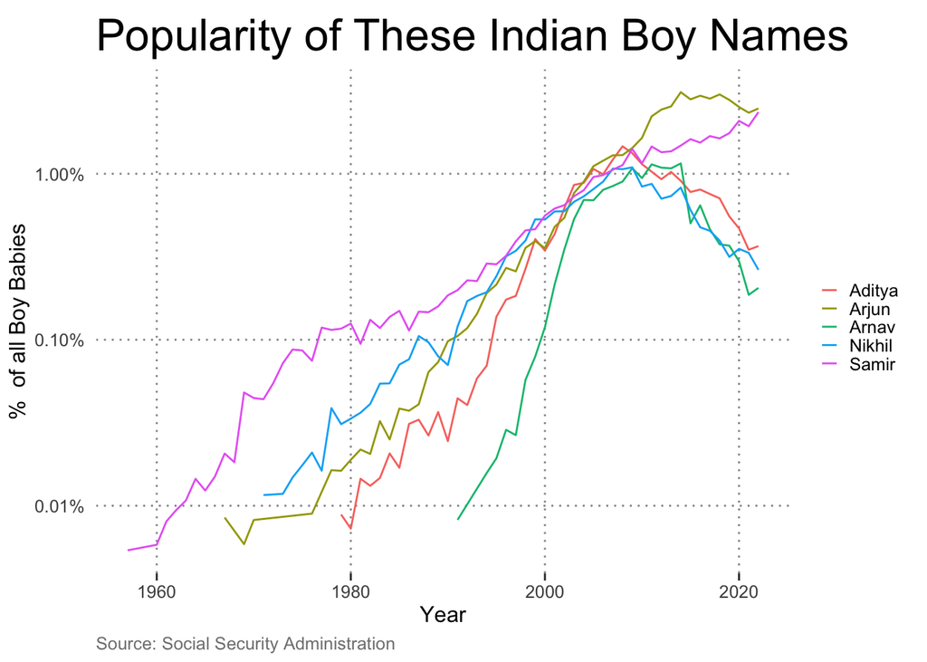

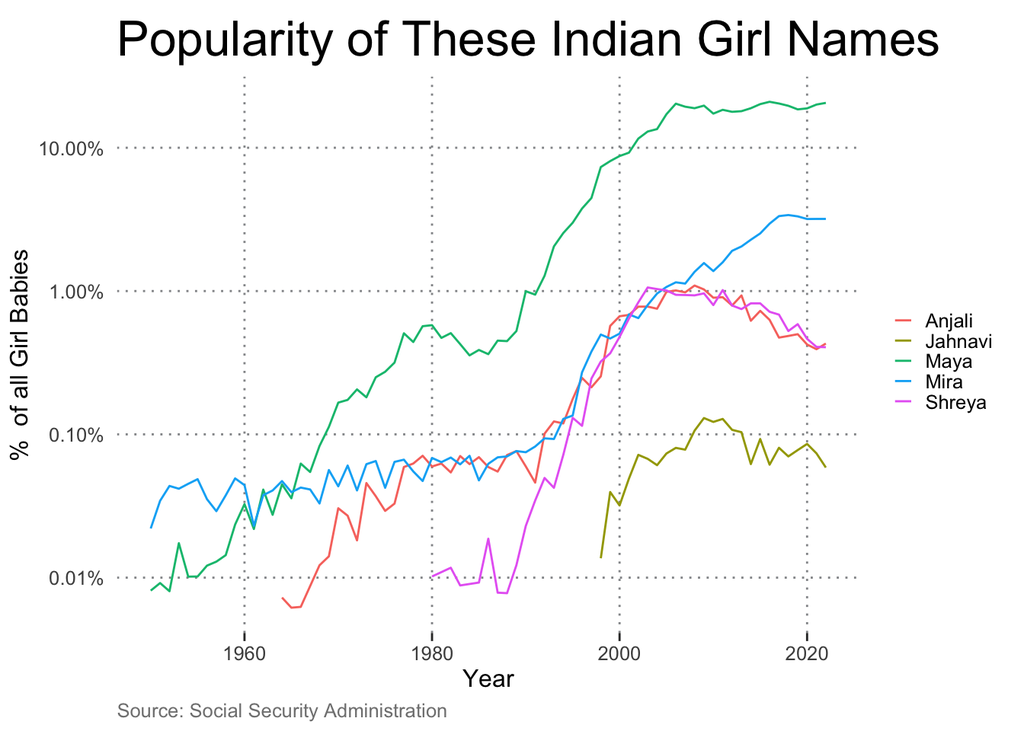

While it’s challenging to predict the exact future trend of Indian names and whether we’ll witness a significant increase in the popularity of names like Jahnavi in the coming decades, one thing remains certain: the dynamic nature of cultural identity will continue to influence parental choices. As the Indian diaspora expands and subsequent generations navigate the delicate balance between heritage and assimilation, it is probable that we will observe a sustained appreciation for South Asian names. Through the unique experiences of individuals like Jahnavi Alapati, we are reminded of the enduring spirit to honor one’s roots while forging a path that embraces both tradition and integration into diverse societies.

## References

- CREDO National Charter School Study 2013: http://credo.stanford.edu/documents/NCSS%202013%20Final%20Draft.pdf
- NBER Working Paper No. 23947: The Labor Market Effects of Offshoring by U.S. Multinational Firms: Evidence from Changes in Global Tax Policies: http://www.nber.org/papers/w23947
- SSA Website: Beyond the Top 1000 Names: https://www.ssa.gov/oact/babynames/limits.html
- Indian Immigrants in the United States: https://www.migrationpolicy.org/article/indian-immigrants-united-states